# Data Analysis with R

## Content

1. The linear model `lm()`
2. Simple regression
   - continuous predictors
   - categorical predictors
3. Multiple regression
   - main effect models
   - interaction models
4. Residual plots

## Linear Model

The linear regression model:

\[y_i=\beta_0+\beta_{1} x_{i1}+\beta_2x_{i2}+\dots+\varepsilon_i, \ \ \ \ \ \ \varepsilon_i\sim N(0, \sigma^2)\] where

- \(y_i\) is score of individual \(i\) on the numeric dependent variable \(Y\)
- \(x_{i1}\) is the score of individual \(i\) on predictor \(X_1\)
- \(\beta_0\) is the intercept
- \(\beta_1\) is the slope of \(X_1\)
- \(\varepsilon_{i}\) is the residual (prediction error)
- \(\sigma^2\) is the variance of the residuals

## The `lm()` function

```r
lm(formula, data) # returns an object of class lm
```

| formula | model |
| --- | --- |
| `y ~ 1` | intercept-only |
| `y ~ x1` | main effect of x1 |
| `y ~ x1 + x2` | main effects of x1, x2 |
| `y ~ .` | main effects of all predictors |
| `y ~ . - x1` | main effects of all predictors except x1 |
| `y ~ x1 + x2 + x1:x2` | main effects + interaction between x1 and x2 |
| `y ~ x1*x2` | idem |
| `y ~ .^2` | main effects + pairwise interactions between all predictors |

## Simple regression

## Continuous predictor

\[y_i=\hat{y}_i+\varepsilon_i\] where \[\hat{y}_i=\beta_0 + \beta_1x_i\]

- \(\hat{y}_i\) is the fitted value of \(y_i\) for \(X=x_i\)
- \(x_i\) is the score on the numeric predictor
- \(\varepsilon_i\) is the residual
- \(\beta_0\) is the fitted value for \(X = 0\)
- \(\beta_1\) is the change in the fitted value for unit increase in \(X\)

## `mtcars` data

The help file of the `mtcars` data provides the following information on the data:

*The data was extracted from the 1974 Motor Trend US magazine, and comprises fuel consumption and 10 aspects of automobile design and performance for 32 automobiles (1973–74 models).*

We will consider the following three variables of this data set:

- `mpg` (numerical): miles per gallon, the determinant of fuel efficiency.
- `disp` (numerical): displacement measures overall volume in the engine as a factor of cylinder circumference, depth and total number of cylinders. This metric gives a good proxy for the total amount of power the engine can generate.
- `gear` (numeric): Number of forward gears. Number of gears in the transmission. Manual transmissions have either 4 or 5 forward gears; Automatic either 3 or 4.

## Information about the data set

```r
str(mtcars)
```

```
'data.frame':   32 obs. of  11 variables:
 $ mpg : num  21 21 22.8 21.4 18.7 18.1 14.3 24.4 22.8 19.2 ...
 $ cyl : num  6 6 4 6 8 6 8 4 4 6 ...
 $ disp: num  160 160 108 258 360 ...
 $ hp  : num  110 110 93 110 175 105 245 62 95 123 ...
 $ drat: num  3.9 3.9 3.85 3.08 3.15 2.76 3.21 3.69 3.92 3.92 ...
 $ wt  : num  2.62 2.88 2.32 3.21 3.44 ...
 $ qsec: num  16.5 17 18.6 19.4 17 ...
 $ vs  : num  0 0 1 1 0 1 0 1 1 1 ...
 $ am  : num  1 1 1 0 0 0 0 0 0 0 ...
 $ gear: num  4 4 4 3 3 3 3 4 4 4 ...
 $ carb: num  4 4 1 1 2 1 4 2 2 4 ...
```

## Linear model

```r
lm(formula = mpg ~ disp, data = mtcars)
```

```
Call:
lm(formula = mpg ~ disp, data = mtcars)

Coefficients:
(Intercept)         disp
   29.59985     -0.04122
```

For `disp = 0`, the predicted value of `mpg` is 29.6

For each unit increase in `disp`, the predicted value of `mpg` decreases with 0.041

(i.e. cars with higher engine power consume more fuel)

## The `lm` object

Extracting information from an `lm` object called `fit`:

| Function / Subsetting | Output |
| --- | --- |
| `summary(fit)` | summary of the model |
| `coef(fit) / fit$coef` | coefficients |
| `coef(summary(fit)) / summary(fit)$coef` | coefficients, SEs, \(t\)-values, \(p\)-values |
| `fitted(fit) / fit$fitted` | fitted values |
| `resid(fit) / fit$resid` | residuals |
| `anova(fit)` | ANOVA table |
| `plot(fit)` | residual plots |

## Extracting the coefficients

```r
summary(lm(mpg ~ disp, mtcars))$coef %>% round(3)
```

```
            Estimate Std. Error t value Pr(>|t|)
(Intercept)   29.600      1.230  24.070        0
disp          -0.041      0.005  -8.747        0
```

The intercept is significantly different from 0

The slope is significantly different from 0

## Scatterplot

Display a scatter plot with linear regression line for the previous model.

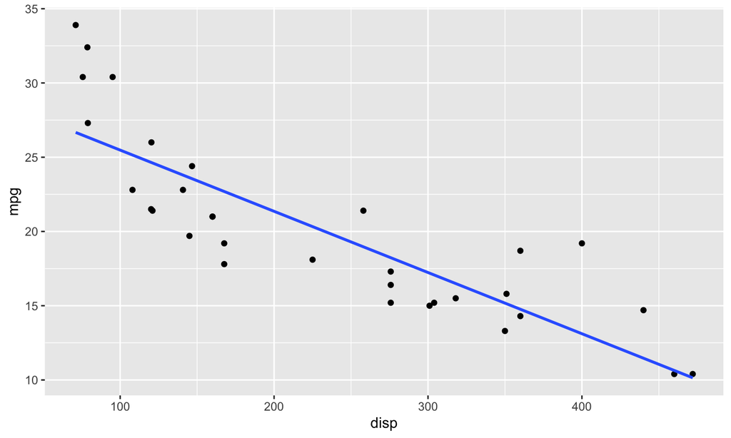

## Categorical predictor

A predictor with \(k\) categories is converted into \(k-1\) dummy variables.

- one dummy per category, except for the reference category
- dummy has value \(1\) for corresponding category and \(0\) otherwise
- the reference category has value \(0\) on all dummies

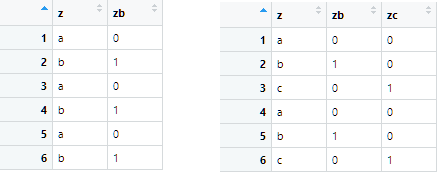

Reference category of \(z\) is \(a\)

## Interpreting dummies

Model with two dummies \(zb\) and \(zc\):

\[\hat{y}=\beta_0+\beta_1zb+\beta_2zc\]

- \(\beta_0\) is fitted value for \(z=a\) (reference category)
- \(\beta_0+\beta_1\) is the fitted value for \(z=b\)
- \(\beta_0+\beta_2\) is the fitted value for \(z=c\)

## Linear model with `gear` as factor

`gear` is a categorical variable and has values 3, 4, 5, and has data type numeric.

```r
lm(mpg ~ factor(gear), mtcars)
```

```
Call:
lm(formula = mpg ~ factor(gear), data = mtcars)

Coefficients:
  (Intercept)  factor(gear)4  factor(gear)5
       16.107          8.427          5.273
```

- mean `mpg` for 3 gears is 16.107
- mean `mpg` for 4 gears is 16.107 + 8.427
- mean `mpg` for 5 gears is 16.107 + 5.273

## Regression lines

Two plots, each with reference category `gear = 3`

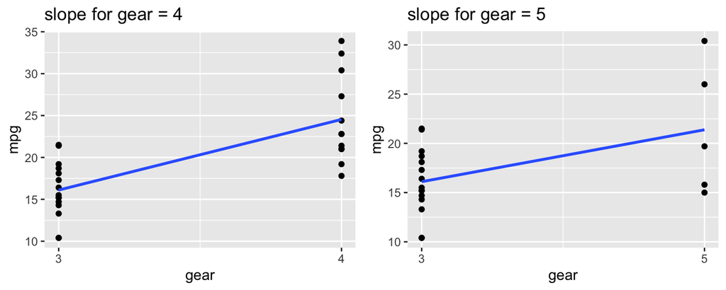

## Model summary

Summary of model statistics

```
Call:
lm(formula = mpg ~ factor(gear), data = mtcars)

Residuals:
    Min      1Q  Median      3Q     Max
-6.7333 -3.2333 -0.9067  2.8483  9.3667

Coefficients:
              Estimate Std. Error t value Pr(>|t|)
(Intercept)     16.107      1.216  13.250 7.87e-14 ***
factor(gear)4    8.427      1.823   4.621 7.26e-05 ***
factor(gear)5    5.273      2.431   2.169   0.0384 *
---
Signif. codes:  0 '***' 0.001 '**' 0.01 '*' 0.05 '.' 0.1 ' ' 1

Residual standard error: 4.708 on 29 degrees of freedom
Multiple R-squared:  0.4292,    Adjusted R-squared:  0.3898
F-statistic:  10.9 on 2 and 29 DF,  p-value: 0.0002948
```

## Model comparisons with `anova()`

Which model fits better:

1. `mpg ~ 1`
2. `mpg ~ gear`
3. `mpg ~ factor(gear)`

Each subsequent model has one more parameter, so it is expected to fit better.

- But is it significantly better?

We can check this with an \(F\)-test for the \(R^2\)-change

- The function to do this test is `anova(model 1, model 2, model 3)`

## Which model fits best?

Test the \(R^2\)-change for the 3 models on the previous slide

- which model fits best?

```r
anova(lm(formula = mpg ~ 1, data = mtcars),
      lm(formula = mpg ~ gear, data = mtcars),
      lm(formula = mpg ~ factor(gear), data = mtcars))
```

```
Analysis of Variance Table

Model 1: mpg ~ 1
Model 2: mpg ~ gear
Model 3: mpg ~ factor(gear)
  Res.Df    RSS Df Sum of Sq      F   Pr(>F)
1     31 1126.0
2     30  866.3  1    259.75 11.719 0.001864 **
3     29  642.8  1    223.49 10.083 0.003534 **
---
Signif. codes:  0 '***' 0.001 '**' 0.01 '*' 0.05 '.' 0.1 ' ' 1
```

Model 3 fits best.

## Multiple regression

## Main-effects model

No interactions in the model, e.g.

\[\hat{y}=\beta_0+\beta_1x_1+\beta_2x_2\]

Interpretation

- the slope of \(x_1\) does not depend on \(x_2\)
- the slope of \(x_2\) does not depend on \(x_1\)
- the slopes of \(x_1\) and \(x_2\) are corrected for the correlation \(r_{x_1,x_2}\)

## Model with `disp` and `gear`

Slopes corrected for correlation `disp` and `gear` \((r = -0.56)\)

Slope for `disp` and `gear` in simple regression models

```r
c(lm(formula = mpg ~ disp, data = mtcars)$coef[2],
  lm(formula = mpg ~ gear, data = mtcars)$coef[2])
```

```
       disp        gear
-0.04121512  3.92333333
```

Slope for `disp` and `gear` in multiple regression model

```r
lm(formula = mpg ~ disp + gear, data = mtcars)$coef[2:3]
```

```
       disp        gear
-0.04084734  0.11120218
```

## Interaction model

An interaction effect is (literally) the product of two predictors:

\[\hat{y}=\beta_0+\beta_1x_1+\beta_2x_2 + \beta_{12}x_1x_2\]

- The main effects should always be included too!

Interpreting the interaction effect

- The slope of \(x_1\) is \(\beta_1+\beta_{12}x_2\).
- The slope of \(x_2\) is \(\beta_2+\beta_{12}x_1\).

## Model summary

```r
summary(lm(formula = mpg ~ disp * factor(gear), data = mtcars))
```

```
Call:
lm(formula = mpg ~ disp * factor(gear), data = mtcars)

Residuals:
    Min      1Q  Median      3Q     Max
-4.5986 -1.5990 -0.0143  1.6329  4.9926

Coefficients:
                    Estimate Std. Error t value Pr(>|t|)
(Intercept)        24.515566   2.462431   9.956 2.32e-10 ***
disp               -0.025770   0.007265  -3.547 0.001505 **
factor(gear)4      15.051963   3.558043   4.230 0.000256 ***
factor(gear)5       7.145380   3.535913   2.021 0.053711 .
disp:factor(gear)4 -0.096442   0.021261  -4.536 0.000114 ***
disp:factor(gear)5 -0.025005   0.013320  -1.877 0.071742 .
---
Signif. codes:  0 '***' 0.001 '**' 0.01 '*' 0.05 '.' 0.1 ' ' 1

Residual standard error: 2.579 on 26 degrees of freedom
Multiple R-squared:  0.8465,    Adjusted R-squared:  0.817
F-statistic: 28.67 on 5 and 26 DF,  p-value: 8.452e-10
```

## Regression plots

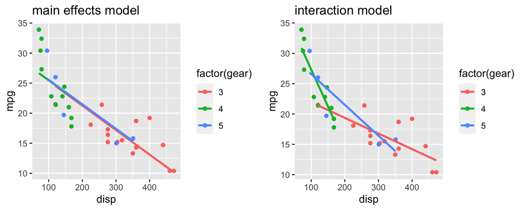

## Compare the models

Compare and interpret the fit of the following models

- intercept-only
- model with `disp` predicting `mpg`
- main effects model with `disp` and `factor(gear)` predicting `mpg`
- interaction model with `disp` and `factor(gear)` predicting `mpg`

## Results

```r
anova(lm(formula = mpg ~ 1, data = mtcars),
      lm(formula = mpg ~ disp, mtcars),
      lm(formula = mpg ~ disp + factor(gear), mtcars),
      lm(formula = mpg ~ disp * factor(gear), mtcars))
```

```
Analysis of Variance Table

Model 1: mpg ~ 1
Model 2: mpg ~ disp
Model 3: mpg ~ disp + factor(gear)
Model 4: mpg ~ disp * factor(gear)
  Res.Df     RSS Df Sum of Sq       F    Pr(>F)
1     31 1126.05
2     30  317.16  1    808.89 121.657 2.651e-11 ***
3     28  317.01  2      0.15   0.011 0.9890201
4     26  172.87  2    144.14  10.839 0.0003771 ***
---
Signif. codes:  0 '***' 0.001 '**' 0.01 '*' 0.05 '.' 0.1 ' ' 1
```

## Residual plots

## Residuals vs Fitted

**linearity**

- approximately straight red line at 0

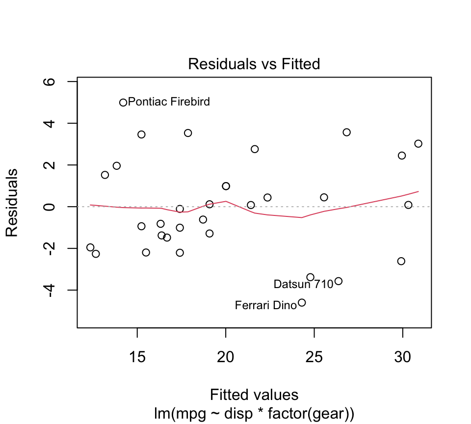

## Normal Q-Q

**Normally distributed residuals**

- residuals approximately on diagonal

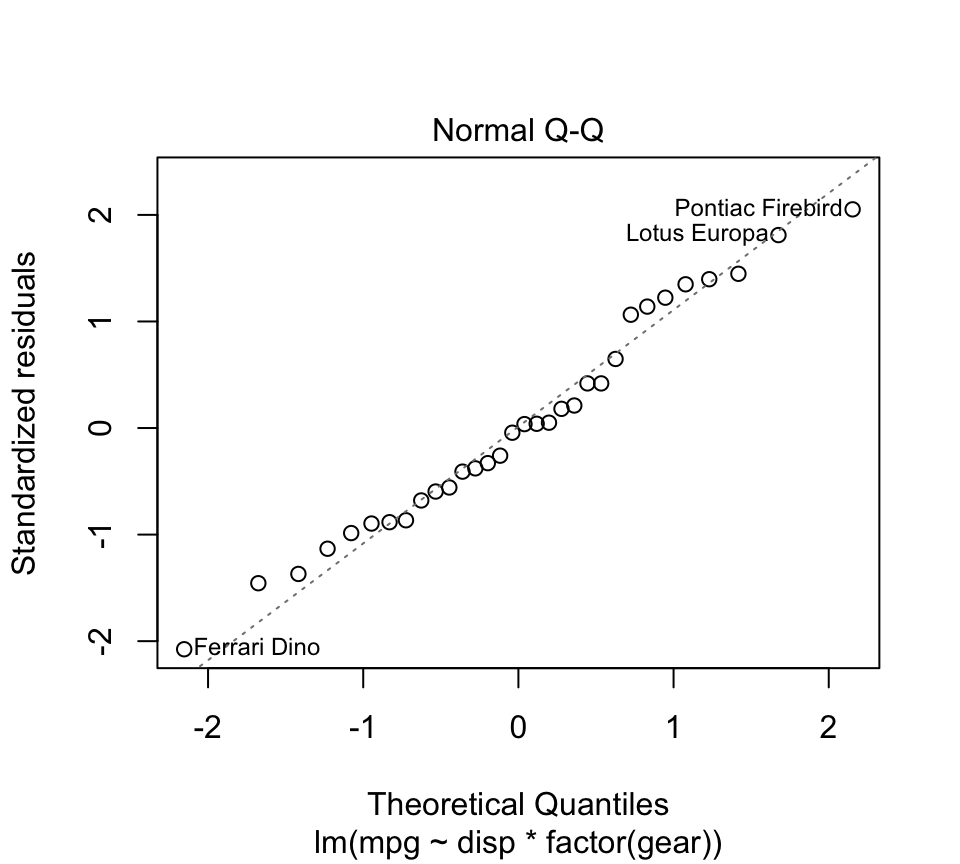

## Scale-Location**

**Homoscedasticity (constant variance residuals)**

- approximately straight red line

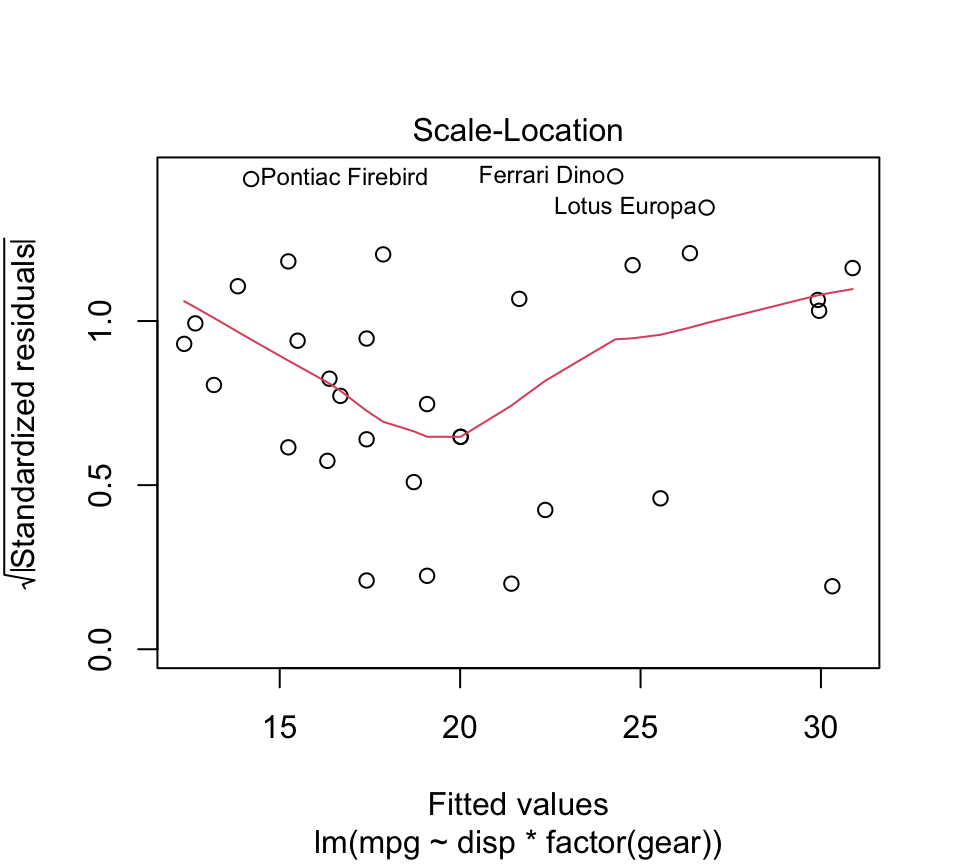

## Residuals vs Leverage

**Influential data points**

- data points with a Cook’s Distance larger than 1

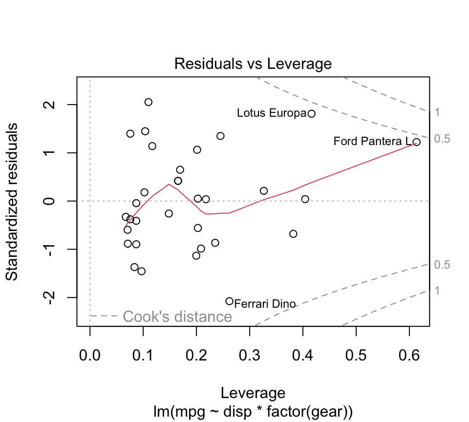